# Inference of Ligand-Receptor Interactions (LRIs) with CellChat and ligand prioritization within the NicheNet framework

31 May, 2024

# 1 Motivation, biological question of interest & analysis design

CellChat is a popular tool for the inference of LR interactions. It models cell-cell communication by accurately describing the protein complexes components involved in LR interactions, such as multisubunit ligand/receptors, co-stimulatory/inhibitory receptor subunits, and ligand agonists/antagonists. Overall, at default parameters, the CellChat framework tends to be more conservative than other approaches. Under the assumptions made by ligand-receptor tools (e.g. the RNA expression is a proxy of protein expression), the interactions inferred by CellChat tend to be supported by stronger evidence in transcriptomics data (e.g. all the components of multi-subunit receptors must be co-expressed).

However, this method does not consider intracellular signalling events, which can provide potential evidence supporting that the inferred LR interactions are inducing active cell-cell communication (CCC) events. If we can capture the differential expression that is putatively induced by CCC events, we can utilize NicheNet to rank the ligands in CellChat LRIs based on their capacity to explain this change in gene expression. Conceptually, these two approaches are complementary, as NicheNet will provide evidence inferred on the downstream effect of the cell-cell communication event (i.e. changes in gene expression).

Here, we show a combined analysis of the two approaches to study the changes in cell-cell communication events taking place in the breast cancer microenvironment of OnE vs OnNE patients upon anti-PD1 treatment (Bassez, A., Vos, H., Van Dyck, L. et al. 2021).

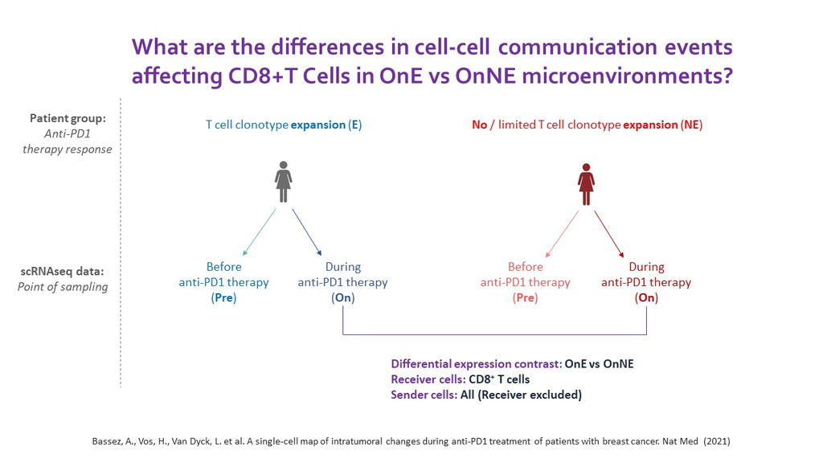

# 2 Practical steps:

- Infer LRIs in the OnE subset via CellChat
- Extract LRIs targeting CD8 positive T Cells and extract the LRIs for the NicheNet model
- Prioritize ligands based on the differential expression between OnE vs OnNE in CD8 positive T cells
- Run a NicheNet sender-focused approach and compare the two outputs

## 2.1 Infer LRIs in the OnE subset via CellChat

### 2.1.1 Loading required packages and DBs

```r
# Load all the required packages
library(SeuratObject)
library(Seurat)
library(SingleCellExperiment)
library(dplyr)
library(multinichenetr)
library(CellChat)
library(splitstackshape)
library(nichenetr)

# Set Human CellChat Database
CellChatDB <- CellChatDB.human

# Download NicheNet LRIs Database & Regulatory prior model
lr_network <- readRDS("lr_network_human_21122021.rds")
ligand_target_matrix <- readRDS("ligand_target_matrix_nsga2r_final.rds")
```

### 2.1.2 Data processing and CellChat Object creation

The full dataset is available at: https://zenodo.org/record/8016880

```r
# Load BC dataset
sce_bc<-readRDS("sce_cohort1_updated.rds")

# Find appropriate aliases (gene names conversion to ensure compatibility with NN V2)
sce_bc<-multinichenetr::alias_to_symbol_SCE(sce_bc, "human") %>%
               multinichenetr::makenames_SCE()
```

```r
# Create a Seurat Obj
seurat_bc <- CreateSeuratObject(counts = SingleCellExperiment::counts(sce_bc),
                                        meta.data = as.data.frame(SingleCellExperiment::colData(sce_bc)))

# Remove the single cell experiment object to optimize RAM space
rm(sce_bc)

# Re-assigns idents
Idents(seurat_bc) <- seurat_bc@meta.data$ident

# Subset the object for CellChat (OnE only) and NicheNet analysis (OnNE+OnE)
seurat_bc_OnE <-subset(seurat_bc, subset = expansion_timepoint == 'OnE')
seurat_bc_OnE_OnNE <-subset(seurat_bc, subset = expansion_timepoint == 'OnE' |
                                            expansion_timepoint == 'OnNE' )

# Normalize data
seurat_bc_OnE<- Seurat::NormalizeData(seurat_bc_OnE)
seurat_bc_OnE_OnNE<- Seurat::NormalizeData(seurat_bc_OnE_OnNE)

# Remove the single cell experiment object to optimize RAM space
rm(seurat_bc)
```

Show the cell types composing our datasets, as well as the normalized counts.

```r
# Show cell types
table(Idents(seurat_bc_OnE))
```

```
##
## Endothelial_cell      Cancer_cell             CD8T             CD4T
##              891             4960             6766             6998
##     Myeloid_cell               NK       Fibroblast      macrophages
##             1861              728             1370             2717
##           T_cell           B_cell           CD4REG              gdT
##              863             3199             2540              863
##        Mast_cell              DCs        monocytes              pDC
##              208              794              176                9
```

```r
# Show normalized counts
GetAssayData(seurat_bc_OnE,"RNA")[20:23,20:21]
```

```
## 4 x 2 sparse Matrix of class "dgCMatrix"
##          BIOKEY_10_On_AAACGGGCAGGCTCAC-1 BIOKEY_10_On_AAACGGGGTACCGCTG-1
## AARSD1                                 .                        .
## AASDH                                  .                        .
## AASDHPPT                               .                        1.986951
## AASS                                   .                        .
```

### 2.1.3 Identify LRIs in the OnE subset using CellChat

```r
## Create a Seurat object for OnE
cellchat_onE <- createCellChat(GetAssayData(seurat_bc_OnE,"RNA"),
                                meta = seurat_bc_OnE@meta.data,
                                group.by = "ident" )

# Specify to use CellChat's LRIs Database
cellchat_onE@DB <- CellChatDB
cellchat_onE <- subsetData(cellchat_onE)
cellchat_onE <- identifyOverExpressedGenes(cellchat_onE)
cellchat_onE <- identifyOverExpressedInteractions(cellchat_onE)
cellchat_onE_unfiltered <-computeCommunProb(cellchat_onE)
cellchat_onE <-filterCommunication(cellchat_onE_unfiltered, min.cells = 10)
cellchat_onE <-computeCommunProbPathway(cellchat_onE)
cellchat_onE <-aggregateNet(cellchat_onE)

cellchat_onE_df<-subsetCommunication(cellchat_onE)
```

```r
# Show CellChat inferred LRIs output
cellchat_onE_df
```

|  | source | target | ligand | receptor | prob | pval | interaction_name | interaction_name_2 | pathway_name | annotation | evidence |
| --- | --- | --- | --- | --- | --- | --- | --- | --- | --- | --- | --- |
| 1 | Fibroblast | Fibroblast | FGF7 | FGFR1 | 0.0031283030 | 0.00 | FGF7_FGFR1 | FGF7 - FGFR1 | FGF | Secreted Signaling | PMC: 4393358 |
| 2 | Endothelial_cell | Fibroblast | PDGFB | PDGFRA | 0.0008293697 | 0.00 | PDGFB_PDGFRA | PDGFB - PDGFRA | PDGF | Secreted Signaling | PMID: 15207812 |
| 3 | Endothelial_cell | Fibroblast | PDGFB | PDGFRB | 0.0030867315 | 0.00 | PDGFB_PDGFRB | PDGFB - PDGFRB | PDGF | Secreted Signaling | PMID: 15207812 |
| 4 | monocytes | Endothelial_cell | VEGFA | FLT1 | 0.0113460739 | 0.00 | VEGFA_VEGFR1 | VEGFA - VEGFR1 | VEGF | Secreted Signaling | KEGG: hsa04370; PMID: 16633338 |
| 5 | monocytes | Endothelial_cell | VEGFA | KDR | 0.0051165863 | 0.00 | VEGFA_VEGFR2 | VEGFA - VEGFR2 | VEGF | Secreted Signaling | KEGG: hsa04370; PMID: 16633338 |
| 6 | monocytes | Endothelial_cell | VEGFA | FLT1_KDR | 0.0082744654 | 0.00 | VEGFA_VEGFR1R2 | VEGFA - VEGFR1R2 | VEGF | Secreted Signaling | PMID: 16633338 |
| 7 | Fibroblast | Endothelial_cell | IGF1 | ITGA6_ITGB4 | 0.0009271210 | 0.00 | IGF1_ITGA6_ITGB4 | IGF1 - (ITGA6+ITGB4) | IGF | Secreted Signaling | PMID: 28190785; PMID: 28873464 |
| 8 | CD8T | macrophages | CCL5 | CCR1 | 0.0368767542 | 0.00 | CCL5_CCR1 | CCL5 - CCR1 | CCL | Secreted Signaling | KEGG: hsa04060 |
| 9 | CD4T | macrophages | CCL5 | CCR1 | 0.0066986976 | 0.00 | CCL5_CCR1 | CCL5 - CCR1 | CCL | Secreted Signaling | KEGG: hsa04060 |
| 10 | NK | macrophages | CCL5 | CCR1 | 0.0242749079 | 0.00 | CCL5_CCR1 | CCL5 - CCR1 | CCL | Secreted Signaling | KEGG: hsa04060 |

[output cut: 2237 more lines]

```r
# Filter our CellChat output for LRIs targeting CD positive T Cells only
cellchat_onE_df_cd8t_target<-cellchat_onE_df%>%
  dplyr::filter(target=="CD8T")

cellchat_onE_df_cd8t_target
```

| source | target | ligand | receptor | prob | pval | interaction_name | interaction_name_2 | pathway_name | annotation | evidence |
| --- | --- | --- | --- | --- | --- | --- | --- | --- | --- | --- |
| Myeloid_cell | CD8T | CXCL9 | CXCR3 | 0.016901607 | 0.00 | CXCL9_CXCR3 | CXCL9 - CXCR3 | CXCL | Secreted Signaling | KEGG: hsa04060 |
| Fibroblast | CD8T | CXCL9 | CXCR3 | 0.006733959 | 0.00 | CXCL9_CXCR3 | CXCL9 - CXCR3 | CXCL | Secreted Signaling | KEGG: hsa04060 |
| macrophages | CD8T | CXCL9 | CXCR3 | 0.017817757 | 0.00 | CXCL9_CXCR3 | CXCL9 - CXCR3 | CXCL | Secreted Signaling | KEGG: hsa04060 |
| DCs | CD8T | CXCL9 | CXCR3 | 0.005387926 | 0.00 | CXCL9_CXCR3 | CXCL9 - CXCR3 | CXCL | Secreted Signaling | KEGG: hsa04060 |
| Myeloid_cell | CD8T | CXCL10 | CXCR3 | 0.009063622 | 0.00 | CXCL10_CXCR3 | CXCL10 - CXCR3 | CXCL | Secreted Signaling | KEGG: hsa04060 |
| macrophages | CD8T | CXCL10 | CXCR3 | 0.017981048 | 0.00 | CXCL10_CXCR3 | CXCL10 - CXCR3 | CXCL | Secreted Signaling | KEGG: hsa04060 |
| monocytes | CD8T | CXCL10 | CXCR3 | 0.008147646 | 0.00 | CXCL10_CXCR3 | CXCL10 - CXCR3 | CXCL | Secreted Signaling | KEGG: hsa04060 |
| macrophages | CD8T | CXCL11 | CXCR3 | 0.003686909 | 0.00 | CXCL11_CXCR3 | CXCL11 - CXCR3 | CXCL | Secreted Signaling | KEGG: hsa04060 |
| monocytes | CD8T | CXCL11 | CXCR3 | 0.003772735 | 0.00 | CXCL11_CXCR3 | CXCL11 - CXCR3 | CXCL | Secreted Signaling | KEGG: hsa04060 |
| CD4T | CD8T | CXCL13 | CXCR3 | 0.012086674 | 0.00 | CXCL13_CXCR3 | CXCL13 - CXCR3 | CXCL | Secreted Signaling | KEGG: hsa04060 |

[output cut: 175 more lines]

```r
# Number of unique ligands putatively targeting CD8 positive T Cells
length(unique(cellchat_onE_df_cd8t_target$ligand))
```

```
## [1] 45
```

**Observations:**

- The current CellChat output depicts all the LRIs in the OnE dataset.
- These LRIs include OnE-specific or LRIs shared with OnNE.
- Downstream CellChat visualization analysis can help for retrieving additional insights into differences between the two conditions. However, the definition of quantitative and qualitative differences is not a trivial task.
- The inference of an LR interaction does not imply an active Cell-Cell communication event taking place.

If we assume that the differential expression of CD8 positive T Cells in OnE vs OnNE conditions reflects the changes in cell-cell communication in the two microenvironments, we can use NicheNet to infer which ligands of those prioritized by CellChat best explain the observed change in gene expression.

## 2.2 Extract LRIs targeting CD8 positive T Cells and extract LRIs defined in the NicheNet model

Before proceeding with a NicheNet analysis of the selected LRIs, we need to perform some additional data manipulation steps to ensure we are only considering LR pairs that are described by our NicheNet LR model.

```r
# Define the receiver population
receiver="CD8T"

# Recode ligands/receptors composed of multiple subunits to single LR pairs
CC_cd8t_single_receptor_lris<-cellchat_onE_df%>%
  dplyr::filter(target==receiver)%>%
  cSplit("receptor", sep = "_", direction = "long")%>%
  cSplit("ligand", sep = "_", direction = "long")%>%
  as.data.frame()%>%
  mutate(lri=paste(ligand , receptor , sep="_" ))

# Define LR pairs in the NicheNet LR DB
lr_network<-lr_network%>%
  distinct(from, to)%>%
  mutate(lri=paste(from,to, sep="_"))


# Select ligands from the NicheNet LR DB based on CellChat results
potential_ligands_CC_lris <- lr_network %>%
  filter(lri %in% CC_cd8t_single_receptor_lris$lri) %>%
  pull(from) %>% unique()

# Show the number of putative ligands
length(potential_ligands_CC_lris)
```

```
## [1] 26
```

## 2.3 Run differential expression analysis and NicheNet ligand prioritization on predicted CellChat LRIs

```r
# Subset Seurat Object for our receiver population and run differential expression analysis
seurat_bc_OnE_OnNE_receiver <- subset(seurat_bc_OnE_OnNE, idents = receiver)
DE_table_receiver <-  FindMarkers(object = seurat_bc_OnE_OnNE_receiver,
                                  ident.1 = "OnE", ident.2 = "OnNE",
                                  group.by = "expansion_timepoint",
                                  min.pct = 0.1) %>% tibble::rownames_to_column("gene")


# Filter Differential expressed genes -> Gene set of interest (GSOI)
geneset_oi <- DE_table_receiver %>% filter(p_val_adj <= 0.01 & abs(avg_log2FC) >= 0.5) %>% pull(gene)
geneset_oi <- geneset_oi %>% .[. %in% rownames(ligand_target_matrix)]
length(geneset_oi)
```

```
## [1] 410
```

```r
# Define the background of expressed genes in receiver cells
expressed_genes_receiver <- get_expressed_genes(receiver, seurat_bc_OnE_OnNE, pct = 0.1)
background_expressed_genes <- expressed_genes_receiver %>% .[. %in% rownames(ligand_target_matrix)]
length(background_expressed_genes)
```

```
## [1] 3871
```

```r
# Potential_ligands_CC_lris
ligand_activities_cellchat <- predict_ligand_activities(geneset = geneset_oi,
                                               background_expressed_genes = background_expressed_genes,
                                               ligand_target_matrix = ligand_target_matrix,
                                               potential_ligands = potential_ligands_CC_lris)%>%
  arrange(desc(aupr))

ligand_activities_cellchat
```

| test_ligand | auroc | aupr | aupr_corrected | pearson |
| --- | --- | --- | --- | --- |
| TNF | 0.6359558 | 0.1997706 | 0.09578883 | 0.176906561 |
| MDK | 0.6212571 | 0.1924637 | 0.08848201 | 0.112236594 |
| CXCL16 | 0.6177746 | 0.1874228 | 0.08344111 | 0.120153983 |
| CD86 | 0.6084472 | 0.1838110 | 0.07982927 | 0.099986555 |
| CXCL12 | 0.6182533 | 0.1832465 | 0.07926472 | 0.105180758 |
| ICAM1 | 0.6158077 | 0.1828721 | 0.07889034 | 0.122099094 |
| CXCL9 | 0.6073357 | 0.1809126 | 0.07693089 | 0.107673394 |
| CXCL10 | 0.6061238 | 0.1784683 | 0.07448653 | 0.100520623 |
| CXCL13 | 0.6090316 | 0.1771404 | 0.07315866 | 0.090213054 |
| SIGLEC1 | 0.6083291 | 0.1752765 | 0.07129479 | 0.139316167 |

[output cut: 16 more lines]

**Observations:**

- Midkine (MDK) has been repeatedly reported in the literature for playing a role in shaping the microenvironment in tumorigenesis as well as having a role in anti-PD-1 immunotherapy.
- Prioritization of ligands mediating immune cell attraction (e.g. CXCL9/10/16) is consistent with paper’s findings (Figure 5f).

**Limitations:**

- Altough these results point to putative biological meaningful findings, we do not know if these ligands are the ones that best explain our gene set of interest. To assess this, we can evaluate which of our CellChat+NicheNet prioritized ligands also show in the top-ranked ligands of a regular sender-focused approach (less conservative in putative ligand selection criteria).

## 2.4 Run a NicheNet sender-focused approach and compare the two outputs

### 2.4.1 Predict ligand activities

```r
# Extract all receptors from NicheNet V2 LR DB
all_receptors <- unique(lr_network$to)
expressed_receptors <- intersect(all_receptors, expressed_genes_receiver)

# Filter ligands based on receptor expression in CD8 T Cells
potential_ligands <- lr_network %>% filter(to %in% expressed_receptors) %>%
  pull(from) %>% unique()


# Predict ligand activities using a sender-agnostic approach
ligand_activities <- predict_ligand_activities(geneset = geneset_oi,
                                               background_expressed_genes = background_expressed_genes,
                                               ligand_target_matrix = ligand_target_matrix,
                                               potential_ligands = potential_ligands)%>%
  arrange(desc(aupr))

ligand_activities
```

| test_ligand | auroc | aupr | aupr_corrected | pearson |
| --- | --- | --- | --- | --- |
| IGFL3 | 0.5000000 | 0.5519909 | 0.44800913 | NA |
| IFNL3 | 0.6283971 | 0.2652704 | 0.16128865 | 0.256553332 |
| IFITM1 | 0.6493379 | 0.2419568 | 0.13797506 | 0.228751125 |
| IFNA1 | 0.6150435 | 0.2413160 | 0.13733425 | 0.244795164 |
| IFNA5 | 0.6232377 | 0.2369632 | 0.13298147 | 0.214903095 |
| IFNA13 | 0.6338505 | 0.2361763 | 0.13219457 | 0.229079235 |
| IFNA7 | 0.6259052 | 0.2352631 | 0.13128138 | 0.211685563 |
| IFNA14 | 0.6247489 | 0.2346879 | 0.13070613 | 0.212137226 |
| IL27 | 0.6173887 | 0.2342238 | 0.13024201 | 0.238741098 |
| IL21 | 0.6313100 | 0.2325237 | 0.12854191 | 0.231262398 |

[output cut: 451 more lines]

```r
# Select sender cells and extract their putative ligands (i.e. expressed genes)
all_celltypes<-levels(seurat_bc_OnE_OnNE@meta.data$ident)
sender_celltypes <- all_celltypes[all_celltypes!=receiver]

list_expressed_genes_sender <-sender_celltypes %>% unique() %>%
  lapply(get_expressed_genes, seurat_bc_OnE_OnNE, 0.1)
expressed_genes_sender <- list_expressed_genes_sender %>% unlist() %>% unique()

# Number of genes expressed by senders cell types
length(expressed_genes_sender)
```

```
## [1] 9963
```

```r
# Subset the ligand activities to only contain expressed ligands from all populations
potential_ligands_focused <- dplyr::filter(ligand_activities,
                                           test_ligand%in%expressed_genes_sender)%>%
  arrange(desc(aupr))

potential_ligands_focused
```

| test_ligand | auroc | aupr | aupr_corrected | pearson |
| --- | --- | --- | --- | --- |
| IFITM1 | 0.6493379 | 0.2419568 | 0.13797506 | 0.228751125 |
| IFNG | 0.6557489 | 0.2302889 | 0.12630717 | 0.220396586 |
| SIGLEC14 | 0.6337660 | 0.2226283 | 0.11864655 | 0.194541058 |
| IL15 | 0.6446156 | 0.2221493 | 0.11816755 | 0.209112764 |
| CD274 | 0.6446266 | 0.2156998 | 0.11171810 | 0.182221285 |
| EBI3 | 0.6083958 | 0.2109875 | 0.10700578 | 0.179579099 |
| ANGPTL4 | 0.6208204 | 0.2086872 | 0.10470547 | 0.148876555 |
| LIF | 0.6123950 | 0.2072035 | 0.10322176 | 0.173702967 |
| PTPRC | 0.6229795 | 0.2046312 | 0.10064950 | 0.156785275 |
| OSM | 0.6249546 | 0.2045809 | 0.10059916 | 0.161721599 |

[output cut: 217 more lines]

### 2.4.2 Compare the rankings of the two approaches: CellChat+NicheNet vs NicheNet (Sender-focused approach)

To finish our comparison, we plot on the left the CellChat+NicheNet prioritized ligands and on the right the top 75 ligands prioritized by NicheNet (Sender-focused approach).

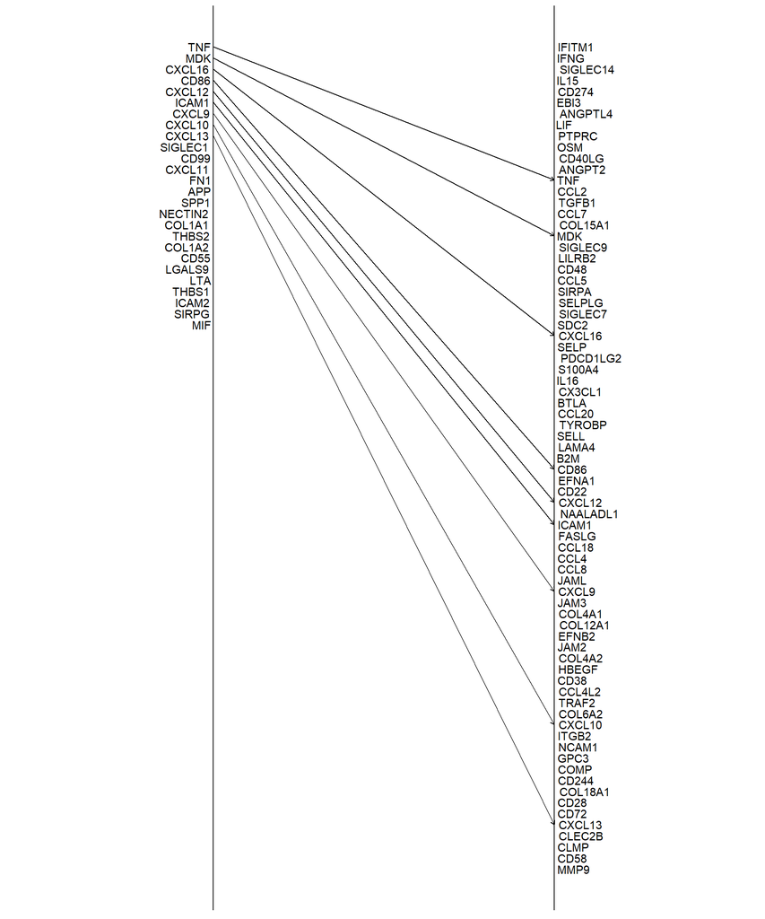

```r
library(reshape2)
library(ggplot2)

## Steps:
# given two outputs of the function: "predict_ligand_activities"
# in this case: predicted_ligands , predicted_ligands_GRN_update (NN,ligand_activities_cellchat)

# 1. generate two df with two cols: ligand, rank
NN_ligand_auc_ranked_df<-as.data.frame(arrange(potential_ligands_focused,desc(aupr_corrected))%>%
                                         mutate(rank=c(1:nrow(.))))%>%select(test_ligand,rank)

CCNN_ligand_auc_ranked_df<-as.data.frame(arrange(ligand_activities_cellchat,desc(aupr_corrected ))%>%
                                          mutate(rank=c(1:nrow(.))))%>%select(test_ligand,rank)

# 2. merge over ligands
merged_rank<-merge(NN_ligand_auc_ranked_df,
                   CCNN_ligand_auc_ranked_df,
                   by="test_ligand",all.x=T, all.y=T)%>%arrange(rank.x)


# 3. Create a dataframe for ggplot2 plotting
names<-merged_rank$test_ligand
ranking_NN<- merged_rank$rank.x
ranking_CCNN<-merged_rank$rank.y

dat <- data.frame(team=names,
                  rankA=ranking_CCNN,rankB=ranking_NN)

#turn the df into a melted version
dat_m <- melt(dat,id.var="team")%>%arrange(desc(value))


# 4. plot:  ligands from CellChat LRI predictions (ranked using NicheNet) vs NicheNet Sender-Focused Approach
ggplot(dat_m, aes(x=variable, y=value, group=team)) +
  geom_line(arrow = arrow(length = unit(0.15, "cm"))) +
  geom_text(data=dat_m[dat_m$variable=="rankA",],aes(label=team),hjust=  1.1 ) +
  geom_text(data=dat_m[dat_m$variable=="rankB",],aes(label=team),hjust= -0.1)+
  geom_vline(xintercept = c(1,2)) +
  theme_classic() +
  theme(
    axis.title = element_blank(),
    axis.line = element_blank(),
    axis.text = element_blank(),
    axis.ticks = element_blank())+ylim(75,1)
```

**Observations and final conclusions:**

- 9 ligands over the 26 inferred by CellChat also show in the top 75 ranked ligands for NicheNet (Sender-focused)
- Concordance between NicheNet and CellChat favourably points to candidates exerting a biological function in the biological context of interest
- The figure clearly shows the conservative behaviour of CellChat run at default parameters. As a side effect, experimentally validated OnE-specific LRIs, such as CD274-PDCD1 (PDL1-PD1), are lost (but captured by NicheNet sender-specific approach).